# Recap & Reporting

# The Agenda

1. Recap
2. How to report results
3. A preview of advanced methods

```r
library(multivariate2017)
library(tidyverse)
library(ggthemes)
library(lme4)
library(boot)
library(RePsychLing)
ay <- ay %>%
        mutate(dob = year-age,
               decade = (dob-1900)/10,
               decade_1960 = (dob-1960)/10,
               log2dur = log2(dur),
               dur_c = log2dur - median(log2dur))
```

# Recap

## Linear Models

*Linear models* attempt to model the relationship between *outcomes* and *predictors* using properties of *lines*. Using the EyeBall Test, we can *see* that there is a relationship between date of birth, F1, and voicing context.

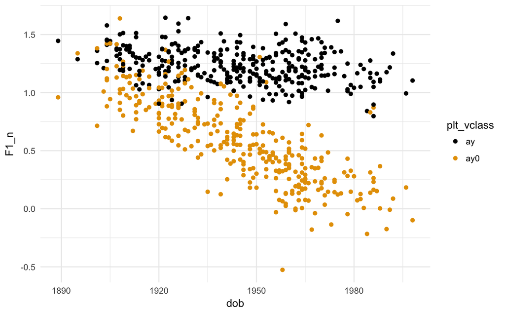

```r
ay_means <- ay %>%
              group_by(idstring, dob, decade, decade_1960, plt_vclass)%>%
              summarise(F1_n = mean(F1_n))
ay_means %>%
  ggplot(aes(dob, F1_n, color = plt_vclass))+
    geom_point()+
    scale_color_colorblind()+
    theme_minimal()
```

We can attempt to *model* this relationship with a few straight lines.

Note:

We don’t know what the *actual* relationship is between these three variables. Just because were fitting a line to the data doesn’t mean the relationship *is* a line.

When fitting any linear model (flat, mixed effects, or generalized) *always* remember that the interpretation of the intercept and slopes are sensitive to scaling of the predictors, and the choice of reference levels.

```r
ay_lm_simple1 <- lm(F1_n ~ decade + plt_vclass, data = ay_means)
ay_lm_simple2 <- lm(F1_n ~ decade_1960 + plt_vclass, data = ay_means)
rbind(`1900` = coef(ay_lm_simple1),
      `1960` = coef(ay_lm_simple2))
```

```
     (Intercept)      decade plt_vclassay0
1900    1.567577 -0.07549335    -0.6433567
1960    1.114617 -0.07549335    -0.6433567
```

```r
ay_lm_interaction1 <- lm(F1_n ~ decade * plt_vclass, data = ay_means)
ay_lm_interaction2 <- lm(F1_n ~ decade_1960 * plt_vclass, data = ay_means)
rbind(`1900` = coef(ay_lm_interaction1),
      `1960` = coef(ay_lm_interaction2))
```

```
     (Intercept)      decade plt_vclassay0 decade:plt_vclassay0
1900    1.326564 -0.02127689    -0.1613291           -0.1084329
1960    1.198902 -0.02127689    -0.8119266           -0.1084329
```

Also remember that the interaction effects are the estimated *difference* from the solo effect. Always draw out the graph that the coefficients are describing. This is especially important when you have categorical predictors interacting.

## When do we use mixed effects?

We use mixed effects models when there are important grouping variables in the data, or variables across which you have made multiple observations. In the case of /ay/, there are some obvious ones:

- the speaker who spoke the vowel
- the word type in which the vowel occured

For other kinds of data, there will be other obvious and less obvious grouping factors:

- participant
- test item
- the research asssistant who ran the experiment
- the day of the week
- etc.

### Why do grouping effects matter?

In a stricty technical sense, the grouping of data points violates the assumption of linear regression that observations are Independent and Identically Distributed (i.i.d.). That is, a collection of data points from the same speaker will be more highly correlated with themselves than data points from another speaker.

But in another important sense, if we ignore that these grouping factors, we’re going to be over confident in our estimates. The flat models are assuming we are working with *a lot* of independent data points:

```r
nrow(ay)
```

```
[1] 84713
```

But, there are a lot fewer speakers:

```r
length(unique(ay$idstring))
```

```
[1] 326
```

And a lot fewer word types:

```r
length(unique(ay$word))
```

```
[1] 959
```

When we’re trying to estimate the effect of decade or duration on /ay/, we need to take into account that we’re working with ~85,000 tokens drawn from only ~330 speakers and ~960 words. This becomes *crucially* important when there is imbalance across these grouping factors. Not all speakers, and far from all words were equally sampled.

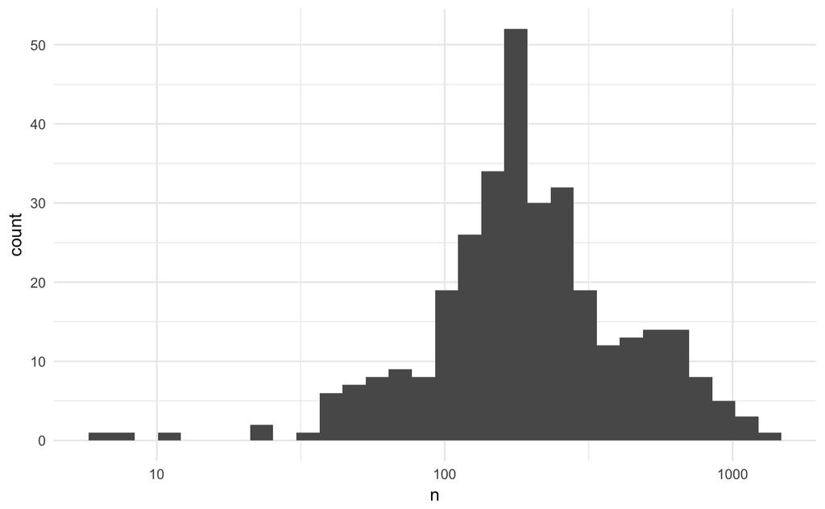

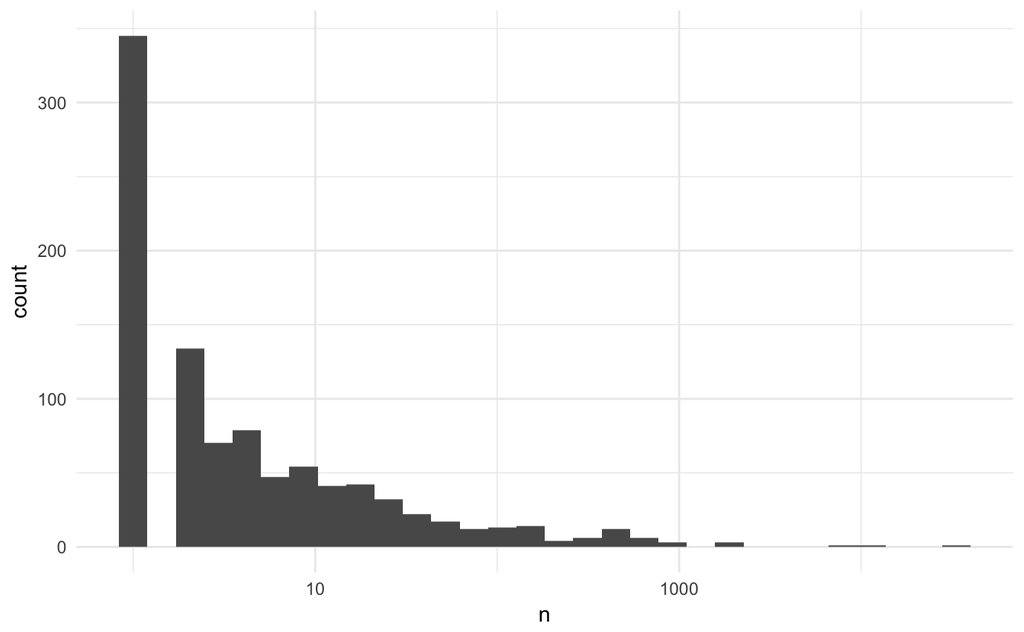

In fact, **40% of all the /ay/ data came from one word!**

```r
ay %>%
  count(word)%>%
  mutate(prop = n/sum(n))%>%
  filter(n == max(n))
```

| word | n | prop |
| --- | --- | --- |
| i | 33351 | 0.393694 |

And, in fact, there’s a lot of reasons to think that the pronoun “I” might behave differently! Without taking that into account, our estimated effects might wind up being a more accurate model of how “I” behaves, instead of how the phoneme /ay/ behaves!

### What *are* random effects?

Random effects allow us to do “partial pooling” of data drawn from our grouping factors. The flat model is complete pooling

[figure not shown]

It doesn’t take into account the fact that the big data pool is drawn sub-pools of speakers.

You could try to model the data using no-pooling.

[figure not shown]

This approach tries to fit a best fitting model for each speaker, but comes with other complications. Each subset of the data is smaller, meaning we wind up with high uncertainty within each model. It’s also the case that the model within each sub-dataset is estimated completely independently of all the others, even though we kind of *suspect* that that the parameters for each speaker should be related in some way to the other speakers.

It’s also the case that we will often have multiple and *overlapping* pooling factors, meanign this would be a fully generalizable approach.

[figure not shown]

Mixed effects models allow us to do “partial pooling.” The parameter predictions for each speaker share information across speakers, making the most of the data structure, while still taking into account the pooling of the data.

## What are the assumptions of a mixed effects model?

A mixed effects model assumes that the random effects (that is, the pooling factors) are drawn from a *normal distribution*. If we think of the fixed effects as the mean (represented by $\mu$) of the distribution, the model estimates the standard deviation (represented by $\sigma$) of the distributuon.

[figure not shown]

Placing this assumption on the predicted random effects for each speaker (or other pooling factor), results in “shrinkage.” That is, for speakers with little data, or extreme estimates under a no-pooling approach, they pull their estimates closer in toward the mean.

### How is this assumption violated?

As far as assumptions go, this one will be commonly vilated. Here are a few scenarios:

- There are subgroups of speakers drawn from normal distributions with different means.
  - Possible fix: include relevant between-groups fixed effects predictors.
- The response variable a.k.a. the outcome variable a.k.a. dependent variable isn’t normally distributed
  - Possible fix: transform your response variable if appropriate.
- There are subgoups of speakers who are drawn from norma distributions with different standard deviations:
  - Not addressible.

Another aspect of modelling the data that also can’t be addressed is that each grouping factor might have its own standard deviation to their data, not just their own mean. This just isn’t modelled in LMEs, at least not as modelled in lme4.

### Why not just more fixed effects?

If we think speakers might have their own individualized effect of duration on pronunciation, for example, why don’t we include a speaker:duration interaction? First, from a practical perspective, this would produce an enormous number of coefficients and would be nearly uninterpretable. Second, it winds up being equivalent to the no-pooling approach.

## When can’t we use mixed effects?

There are a few scenarios under which we are unable to estimate a random effect. The most clear cut cases are when the nature of the data logically eliminates the possibility of a random effect. Consider the two predictors “date of birth”" and “voicing context”. Recall `plt_vclass` stands for different voicing contexts. Let’s look at the data from one sample speaker

```r
sp1 <- ay %>% filter(idstring == idstring[1])
```

If we make a table of all of the values of `dob` in this one speaker’s data, we can see that there is only one unique value:

```r
table(sp1$dob)
```

```
1979
 488
```

This speaker was born in 1979. As a variable that varies between speakers, it is logically the case that all speakers will only have one date of birth. As such, it’s impossible to fit a random slope of `(dob|idstring)`, because there is no way for any given individual speaker to have a *slope* for date of birth.

On the other hand, let’s look at a table of unique values of `plt_vclass`

```r
table(sp1$plt_vclass)
```

```
 ay ay0
395  93
```

This speaker (and most speakers) produced many words, some of which had /ay/ in a pre-voiceless context, and some of which had /ay/ elsewhere. That means it is possible for each speaker to have an idiosyncractic effect of voicing, meaning we can fit a random slope like `(plt_vclass | idstring)`.

On the other hand, let’s look at the data from just one word.

```r
like <- ay %>% filter(word == "LIKE")
```

If we make a table of unique dates of birth which “like” appears in, there’s very many.

```r
table(like$dob)
```

```
1889 1895 1901 1903 1904 1905 1907 1908 1909 1910 1911 1912 1913 1914 1915 1916 1917 1919
  22   78   27   22   35    9   69   54   69   23   43   21   49   40   49   54  152    5
1920 1921 1922 1923 1924 1925 1926 1927 1928 1929 1930 1931 1932 1933 1934 1935 1936 1937
 105   76   46   83   44  120   68   13  213    6   53   68  165   27    3  216   20   72
1938 1939 1940 1941 1942 1943 1944 1945 1946 1948 1949 1950 1951 1952 1953 1954 1955 1956
  31  102   16  303   56  203  283  225  362  169  181   99   45   94  140   72  176  127
1957 1958 1959 1960 1961 1962 1963 1964 1965 1966 1967 1968 1969 1970 1971 1972 1973 1974
  83   62  216  254  130  287  123  227  283  161   16   64   24  155  173   61   12  287
1975 1976 1977 1978 1979 1980 1981 1982 1983 1984 1985 1986 1987 1988 1990 1991 1992 1996
  14   40  155  299  125  155  148  745   21  302   23  173   38  400  294  177   21   34
1998
  72
```

This is because speakers across many different dates of birth said “like”. This means we’re able to fit a random slope like `(dob|word)`.

On the other hand, if we make a table of unique values of the voicing context, we get a different result:

```r
table(like$plt_vclass)
```

```
  ay0
10757
```

The word “like” ends in a /k/, which means that all /ay/ tokens that appear in the word “like” will always be followed by /k/, which is a voiceless consonant. In fact, the voicing context will always be the same within each word, meaning we’re logically unable to fit a random slope of voicing by word, i.e. `(plt_vclass | word)`.

There are also some circumstances where we’re not logically prevented from fitting a random effect, but we are practically prevented. For example, suppose we did a reaction time experiment to see how quickly people could grab a ruler that was dropped between their fingers. We did one trial with all participants, then they all had a coffee, then we ran another trial.

| participant | pre_coffee | post_coffee | diff |
| --- | --- | --- | --- |
| a | 67.70605 | 52.06875 | 15.637296 |
| b | 54.61709 | 52.11914 | 2.497954 |
| c | 55.35991 | 42.93699 | 12.422916 |
| d | 53.80845 | 44.67979 | 9.128651 |
| e | 43.22248 | 36.89715 | 6.325331 |
| f | 57.00134 | 47.18750 | 9.813843 |
| g | 55.90466 | 44.42702 | 11.477639 |
| h | 33.17818 | 26.69120 | 6.486988 |
| i | 44.97613 | 34.47660 | 10.499534 |
| j | 40.65885 | 29.96863 | 10.690219 |

For every speaker, we wind up having one difference score (pre and post) to work with. *Logically* speaking, each participant might have an idiosyncratic effect of coffee on their reaction time. If we had multiple observations from each participant, we could definitely fit a random slope of `(coffee|participant)`. However, in practice, we have only one difference score per person, so the model wouldn’t be able to estimate a random slope by speaker.

## How do you specify the fixed effects?

Model specification is an area of considerable debate. If you are in a position of not know what *any* of the effects of the predictors in your model ought to be, then I would suggest that mixed effects modelling is not your most effective first port of call.

Following the recommendations of Gelman & Hill (2006), I would recommend:

- Include the predictors that are *known* to have an effect, or have been widely discussed in the literature.
- Consider including interactions for the predictors that have a large effect.
- Include predictors directly related the question at hand. You should be fitting models with a purpose.

## How do you specify random effects?

There are currently two schools of thought regarding how to specify the random effects structure of a mixed effects model. [The first recommends that you fit a Maximal Model](https://www.sciencedirect.com/science/article/pii/S0749596X12001180?via%3Dihub). This means that you should fit a model with all possible random slopes and intercepts that are logically possible given the data. The recommendation, in case you get a convergence error,p is to re-fit the model without the covariance structure using the double pipe notation, i.e. `(predictors || groups)`.

[A second approach recommends that you fit a Parsimonious Model](https://arxiv.org/abs/1506.04967). Their recommended workflow is to run a principal components analysis on the random effects structure using `RePsychLing::rePCA()`. If there is too much structure, then they recommend removing the random effects with the lowers variance, comparing models using likelihood ratio tests.

# How do I report any of this?

We’ve gone over the methods you’ll need to use, but we haven’t really discussed in detail how to *report* them, which is just as crucual a skill to acquire as the ability to fit and understand these models.

We’ll walk through this with the example of looking at the effect of decade, voicing and duration on /ay/ pronunciation.

## Visualize

Every report should begin with a visualization of the phenomena of interest, plotting the rawest data available that is also legible in a graph.

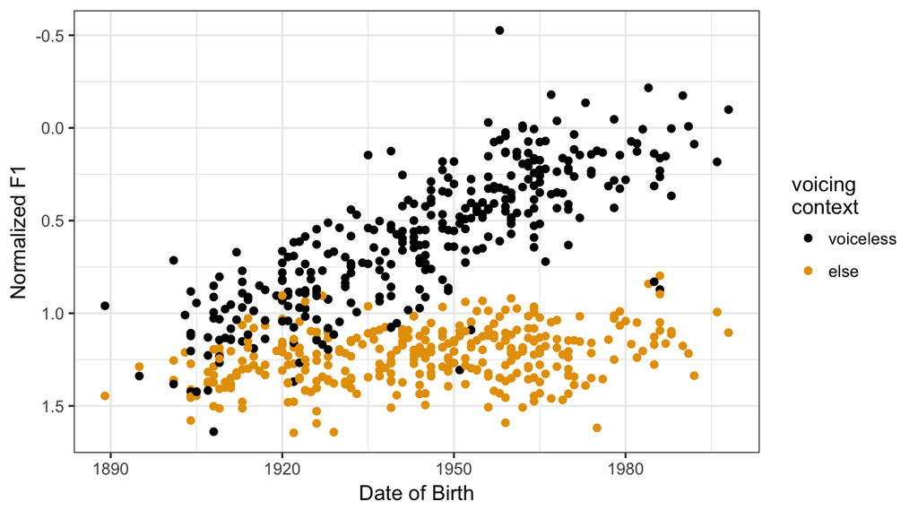

*Figure XX. The relationship between Date of Birth and Normalized F1 on /ay/ by voicing context. Each point represents a by-speaker average.*

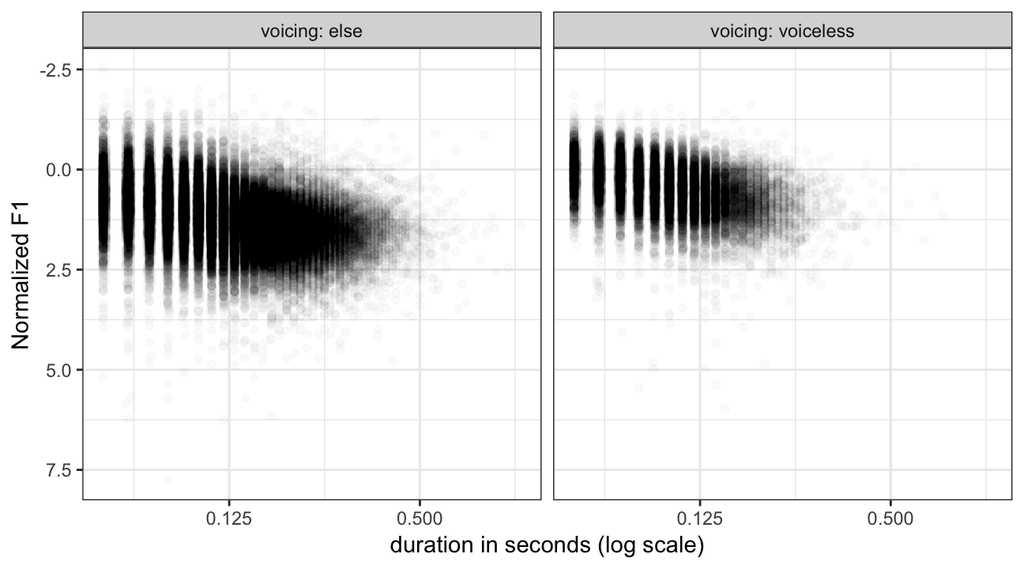

*Figure XX. The relationship between vowel duration and normalized F1.*

There are a number of things about these graphs that make them a bit different from the rest of the graphs I’ve produced so far for this course:

- I’ve renamed the axes so there’s readable and people will know what’s being plotted even if they haven’t read the rest of the paper.
- I’ve recoded the `plt_vclass` variable so that it reads “voiceless” and “else”, again to make the graphs more readable.
- I’ve flipped the y axis direction, because this is actually more conventional for vowel plots of this kind.

## Description of the data.

*The data in this paper is drawn from sociolinguistic interviews with 326 White Philadelphians. In total, this constitutes 84,713 total tokens of /ay/ across 959 word types.*

*For the purpose of modelling, the predictors were scaled and transformed. Date of birth was centered on 1900 and divided by 10. This was done to give us an estimate of the intercept and solitary effects at the turn of the 20th century. Dividing by 10 gives this predictor the interpetation of the rate of change per decade. Duration was log2 transformed, due to its strong rightward skew, and centered at the median. A base of 2 was chosen for the log transform to give the slope the interpretation of the effect of doubling duration.*

## Describe the model!

**BAD**

We fit a mixed effects model with random effects

**GOOD**

*We fit a linear mixed effects model with normalized F1 as the outcome variable, with fixed effects of voicing, decade, and duration and their three way interaction. In the first instance, we fit a maximal random effects structure, which includes random slopes for duration, voicing and their interaction by speaker, and random slopes for duration, decade, and their interaction by word.*

It couldn’t hurt to include some pseudocode for the model:

```
norm_F1 ~ decade * duration * voicing +
    (duration*voicing | speaker) +
    (decade*duration|word)
```

Notice that in my pseudocode here I didn’t actually write out what the data columns are actually called in my data frame. With the exception of some very standardized data contexts, no one will understand what `dur_c` means, or what `idstring` means.

On the point of whether or not you should continue with the maximal model, we can look at the results of `rePCA()`.

```r
summary(rePCA(ay_max_max_model))
```

```
$word
Importance of components%s:
                         [,1]    [,2]    [,3]    [,4]
Standard deviation     0.4410 0.12339 0.02418 0.02080
Proportion of Variance 0.9229 0.07224 0.00277 0.00205
Cumulative Proportion  0.9229 0.99517 0.99795 1.00000

$idstring
Importance of components%s:
                         [,1]   [,2]   [,3]    [,4]
Standard deviation     0.3581 0.2858 0.1671 0.08254
Proportion of Variance 0.5241 0.3340 0.1141 0.02785
Cumulative Proportion  0.5241 0.8580 0.9721 1.00000
```

## Table of the results.

The most important thing that I should hope you take away from this lecture is to please *always always always* report all of the estimated fixed effects.

- Please don’t just report which effects were significant and which were non-significant.
- Please don’t report just p-values.
- Please don’t just report the estimated effects of the significant effects.

Please always report the estimated fixed effects estimates for *all* of the effects! Now, when you fit a big model, the results come out looking like this:

```r
summary(ay_max_max_model)
```

```
Linear mixed model fit by maximum likelihood  ['lmerMod']
Formula: F1_n ~ decade * dur_c * plt_vclass + (1 + dur_c * plt_vclass |
    idstring) + (1 + decade * dur_c | word)
   Data: ay

     AIC      BIC   logLik deviance df.resid
152128.1 152399.2 -76035.1 152070.1    84684

Scaled residuals:
    Min      1Q  Median      3Q     Max
-5.6614 -0.5845 -0.0168  0.5622 11.6496

Random effects:
 Groups   Name                Variance  Std.Dev. Corr
 word     (Intercept)         0.0578034 0.24042
          decade              0.0004281 0.02069  -0.31
          dur_c               0.0136275 0.11674  -0.76 -0.20
          decade:dur_c        0.0002044 0.01430   0.27  0.04 -0.40
 idstring (Intercept)         0.0155077 0.12453
          dur_c               0.0182485 0.13509  -0.08
          plt_vclassay0       0.0369642 0.19226  -0.58  0.04
          dur_c:plt_vclassay0 0.0129326 0.11372   0.26 -0.76  0.09
 Residual                     0.3419439 0.58476
Number of obs: 84713, groups:  word, 959; idstring, 326

Fixed effects:
                            Estimate Std. Error t value
(Intercept)                 1.271450   0.025894   49.10
decade                     -0.007440   0.004385   -1.70
dur_c                       0.258119   0.024068   10.72
plt_vclassay0              -0.110859   0.045216   -2.45
decade:dur_c                0.016099   0.004632    3.48
decade:plt_vclassay0       -0.095175   0.007488  -12.71
dur_c:plt_vclassay0         0.007117   0.038835    0.18
decade:dur_c:plt_vclassay0 -0.010379   0.007266   -1.43

Correlation of Fixed Effects:
            (Intr) decade dur_c  plt_v0 dcd:d_ dcd:_0 dr_:_0
decade      -0.739
dur_c       -0.342  0.146
plt_vclssy0 -0.551  0.400  0.193
decade:dr_c  0.173 -0.205 -0.800 -0.097
dcd:plt_vc0  0.409 -0.554 -0.083 -0.735  0.117
dr_c:plt_v0  0.248 -0.129 -0.508 -0.287  0.392  0.065
dcd:dr_c:_0 -0.144  0.177  0.404  0.124 -0.512 -0.099 -0.767
```

Don’t just take that fixed effects estimate block and copy-paste it into a table. We need to change the names of the variables so they are human readable. We also don’t need to feel yoked to reporting the effects in the same *order* they came out in the regression. For this regression, I think it’d make sense to report the voicing effects as a secondary block.

[figure not shown]

```r
summary(ay_max_pvalue)
```

```
Linear mixed model fit by REML t-tests use Satterthwaite approximations to degrees of freedom [
lmerMod]
Formula: F1_n ~ decade * dur_c * plt_vclass + (1 + dur_c * plt_vclass |
    idstring) + (1 + decade * dur_c | word)
   Data: ay

REML criterion at convergence: 152129.5

Scaled residuals:
    Min      1Q  Median      3Q     Max
-5.6619 -0.5846 -0.0168  0.5622 11.6497

Random effects:
 Groups   Name                Variance  Std.Dev. Corr
 word     (Intercept)         0.0582788 0.24141
          decade              0.0004326 0.02080  -0.32
          dur_c               0.0141376 0.11890  -0.76 -0.20
          decade:dur_c        0.0002171 0.01474   0.27  0.03 -0.41
 idstring (Intercept)         0.0155545 0.12472
          dur_c               0.0183413 0.13543  -0.08
          plt_vclassay0       0.0370896 0.19259  -0.58  0.04
          dur_c:plt_vclassay0 0.0130280 0.11414   0.26 -0.75  0.09
 Residual                     0.3419407 0.58476
Number of obs: 84713, groups:  word, 959; idstring, 326

Fixed effects:
                             Estimate Std. Error         df t value Pr(>|t|)
(Intercept)                  1.271912   0.025979 442.600000  48.959  < 2e-16 ***
decade                      -0.007509   0.004400 365.000000  -1.707 0.088745 .
dur_c                        0.257396   0.024270 165.900000  10.605  < 2e-16 ***
plt_vclassay0               -0.111643   0.045348 427.400000  -2.462 0.014212 *
decade:dur_c                 0.016219   0.004670 177.600000   3.473 0.000646 ***
decade:plt_vclassay0        -0.095038   0.007510 342.500000 -12.656  < 2e-16 ***
dur_c:plt_vclassay0          0.009585   0.039353  65.800000   0.244 0.808328
decade:dur_c:plt_vclassay0  -0.010809   0.007360  70.300000  -1.469 0.146377
---
Signif. codes:  0 ‘***’ 0.001 ‘**’ 0.01 ‘*’ 0.05 ‘.’ 0.1 ‘ ’ 1

Correlation of Fixed Effects:
            (Intr) decade dur_c  plt_v0 dcd:d_ dcd:_0 dr_:_0
decade      -0.740
dur_c       -0.346  0.150
plt_vclssy0 -0.551  0.401  0.195
decade:dr_c  0.177 -0.208 -0.802 -0.099
dcd:plt_vc0  0.410 -0.555 -0.085 -0.736  0.119
dr_c:plt_v0  0.248 -0.130 -0.507 -0.290  0.393  0.069
dcd:dr_c:_0 -0.146  0.178  0.404  0.128 -0.511 -0.104 -0.772
```

If you are in a situation where you *must* report p-values for the fixed effects, and you use the lmerTest package to do this, you should include the following info in the table caption of the results with the p-values.

*p-values estimated via t-tests using the Satterthwaite approximations to degrees of freedom.*

I would also encourage you to report the random effects structures as well, since they can be informative.

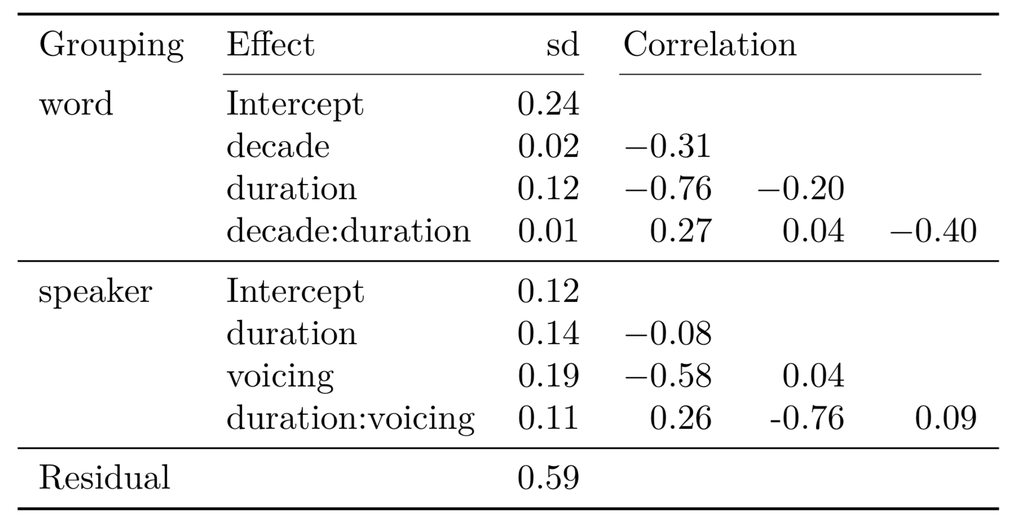

## Model Comparison

*Of specific interest is the interaction between duration and decade, and the three way interaction with voicing. There are no strong pre-existing hypothesis for why the effect of duration should have become strong over the course of the 20th century, so we examined to what degree it improved model fit. In a step-down procedure, we fit another model without the three way interaction, and another without the three way interaction and the two way interaction between duration and decade. We then carried out likelihood ratio tests between these three models, as well as a comparison of AIC and BIC.*

The output of my likelihood ratio test looks like this:

```r
anova(ay_max_max_less2_model, ay_max_max_less1_model, ay_max_max_model)
```

```
Data: ay
Models:
ay_max_max_less2_model: F1_n ~ decade * dur_c * plt_vclass - decade:dur_c:plt_vclass -
ay_max_max_less2_model:     decade:dur_c + (1 + dur_c * plt_vclass | idstring) + (1 +
ay_max_max_less2_model:     decade * dur_c | word)
ay_max_max_less1_model: F1_n ~ decade * dur_c * plt_vclass - decade:dur_c:plt_vclass +
ay_max_max_less1_model:     (1 + dur_c * plt_vclass | idstring) + (1 + decade * dur_c |
ay_max_max_less1_model:     word)
ay_max_max_model: F1_n ~ decade * dur_c * plt_vclass + (1 + dur_c * plt_vclass |
ay_max_max_model:     idstring) + (1 + decade * dur_c | word)
                       Df    AIC    BIC logLik deviance  Chisq Chi Df Pr(>Chisq)
ay_max_max_less2_model 27 152136 152388 -76041   152082
ay_max_max_less1_model 28 152128 152390 -76036   152072 9.8348      1   0.001712 **
ay_max_max_model       29 152128 152399 -76035   152070 1.7809      1   0.182043
---
Signif. codes:  0 ‘***’ 0.001 ‘**’ 0.01 ‘*’ 0.05 ‘.’ 0.1 ‘ ’ 1
```

The general output from this model comparison isn’t so bad, but we need to clean it up a bit to be more human readable.

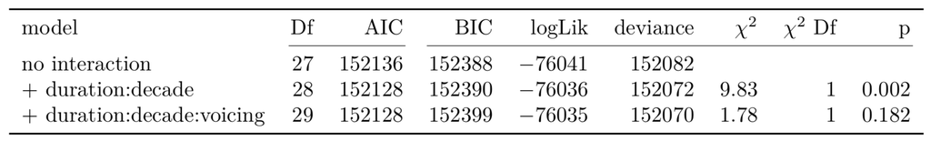

*While the BIC weakly favors the model with no interaction at all, the AIC strongly prefers the model with a duration:decade interaction, as does the significant likelihood ration test. No metrics suggest the three way interaction between duration, decade and voicing are worth the additional model complexity.*

# Preview of more advanced methods

Just like I walked through non-gausian models at the beginning of the course, here I’ll just briefly review some other modelling tools that are out there, just to avoid the symptoms of “when you have a hammer, everything looks like a nail”.

## Nonlinear modelling

Not all relatinships between variables are going to be straight lines!

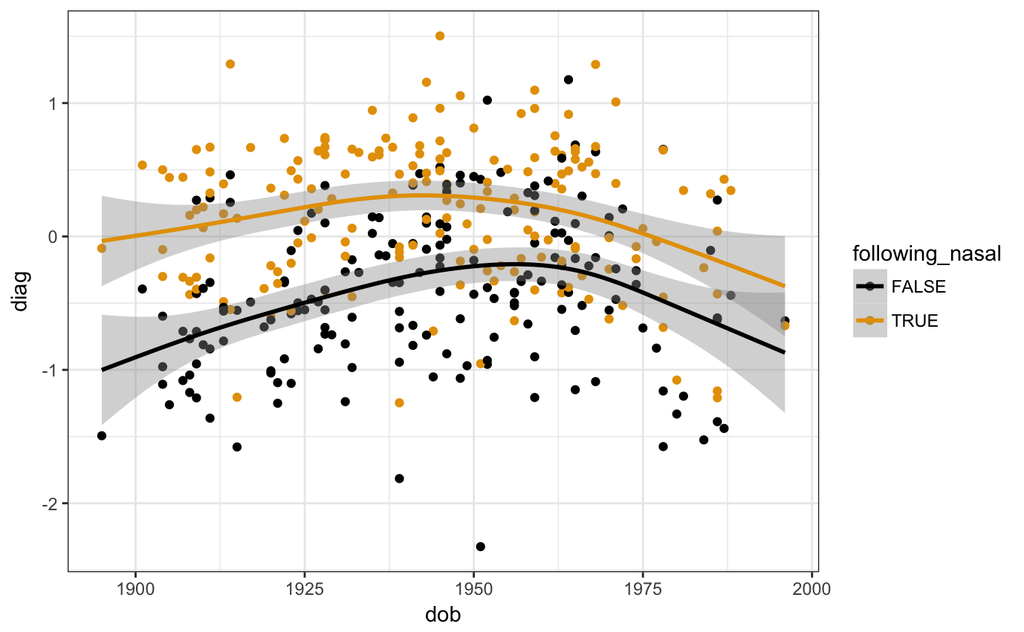

If you have a good theory for *why* this data has the shape it does, then you could incorporate that into a restricted model. However, in this instance, we don’t have such a hypothesis. For situations like this, the current emerging standard is to fit a Genralized Additive Model, using the `mgcv` package.

The nice thing about gams is that in addition to fitting non-linear smooths, you can also incorporate random effects. I’ll show the syntax and some results, but for a tutorial this one by [Jacolien van Rij](http://www.jacolienvanrij.com/Tutorials/GAMM.html) and this one by [Márton Sóskuthy](http://eprints.whiterose.ac.uk/113858/2/1703_05339v1.pdf)

```r
aw_gam <- bam(diag ~ following_nasal +
                      s(dob, by = following_nasal, bs = 'cs') +
                      s(idstring, bs = 're') +
                      s(word, bs = 're'),
              data = aw_to_mod)
```

```r
library(itsadug)
```

```r
colorblind_pal()(2)
```

```
[1] "#000000" "#E69F00"
```

```
Summary:
    * following_nasal : factor; set to the value(s): FALSE, TRUE.
    * dob : numeric predictor; with 30 values ranging from 1895.000000 to 1996.000000.
    * idstring : factor; set to the value(s): PH82-1-10-. (Might be canceled as random effect, check below.)
    * word : factor; set to the value(s): ABOUT. (Might be canceled as random effect, check below.)
    * NOTE : The following random effects columns are canceled: s(idstring),s(word)
```

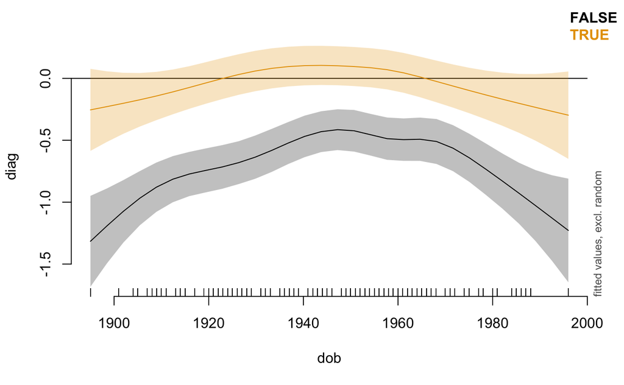

```r
plot_smooth(aw_gam,
            view = "dob",
            plot_all = "following_nasal",
            col = c("#000000","#E69F00"),
            rm.ranef = T)
```

```
Summary:
    * dob : numeric predictor; with 100 values ranging from 1895.000000 to 1996.000000.
    * idstring : factor; set to the value(s): PH82-1-10-. (Might be canceled as random effect, check below.)
    * word : factor; set to the value(s): ABOUT. (Might be canceled as random effect, check below.)
    * NOTE : The following random effects columns are canceled: s(idstring),s(word)


dob window(s) of significant difference(s):
    1895.000000 - 1996.000000
```

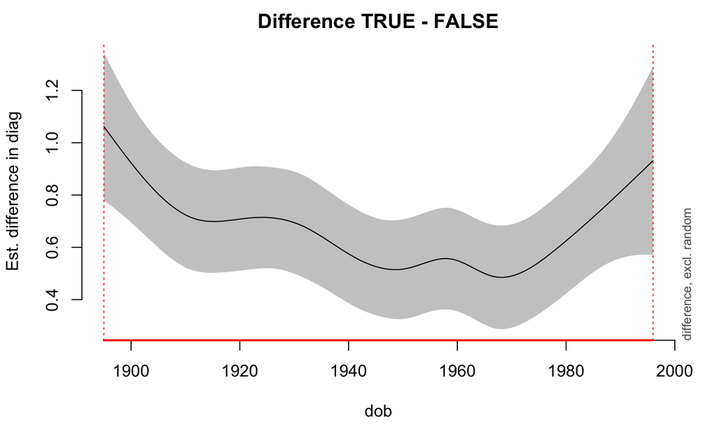

```r
plot_diff(aw_gam, view = "dob",
          comp = list(following_nasal = c("TRUE", "FALSE")),
            rm.ranef = T)
```

## Bayesian & Graphical Modelling

Another avenue to take is to write your own Bayesian Models. I would recommend the book *Doing Bayesian Data Analysis: A Tutorial with R, JAGS, and Stan* to learn more.

```r
library(rstan)
```

```
data{
  int<lower=0> N; //number of observations
  real y[N];      //observed data
  int<lower=0> nspeakers; // number of speakers
  int<lower=0> speaker[nspeakers]; //speaker vector
}
parameters{
  real mu;
  real<lower=0> sigma;
  real speaker_mu[nspeakers];
  real<lower=0> speaker_sigma_scale;
  real<lower=0> speaker_sigma[nspeakers];
}
model{
  real mu_hat[N];
  real sigma_hat[N];

  mu ~ normal(0, 10);
  sigma ~ cauchy(0, 20);
  speaker_mu ~ normal(mu, sigma);
  speaker_sigma ~ cauchy(0, speaker_sigma_scale);

  for(i in 1:N){
    mu_hat[i] = speaker_mu[i];
    sigma_hat[i] = speaker_sigma[i];
  }
  y ~ normal(mu_hat, sigma_hat);
}
```

```r
ayT <- ay %>%
          filter(plt_vclass == "ay0")%>%
          mutate(speaker = as.numeric(factor(idstring)))

ayT_dat <- list(N = length(ayT$F1_n),
                y = ayT$F1_n,
                nspeakers = max(ayT$speaker),
                speaker = ayT$speaker)

ayT_stan <- stan(file = "../sigma_model.stan",
                 data = ayT_dat,
                 iter = 500,
                 chains = 4,
                 verbose = T)
```

```r
library(shinystan)
launch_shinystan(ayT_stan)
```